# ReneWind

Renewable energy sources play an increasingly important role in the global energy mix, as the effort to reduce the environmental impact of energy production increases.

Out of all the renewable energy alternatives, wind energy is one of the most developed technologies worldwide. The U.S Department of Energy has put together a guide to achieving operational efficiency using predictive maintenance practices.

Predictive maintenance uses sensor information and analysis methods to measure and predict degradation and future component capability. The idea behind predictive maintenance is that failure patterns are predictable and if component failure can be predicted accurately and the component is replaced before it fails, the costs of operation and maintenance will be much lower.

The sensors fitted across different machines involved in the process of energy generation collect data related to various environmental factors (temperature, humidity, wind speed, etc.) and additional features related to various parts of the wind turbine (gearbox, tower, blades, break, etc.).

## Objective

“ReneWind” is a company working on improving the machinery/processes involved in the production of wind energy using machine learning and has collected data of generator failure of wind turbines using sensors. They have shared a ciphered version of the data, as the data collected through sensors is confidential (the type of data collected varies with companies). Data has 40 predictors, 20000 observations in the training set and 5000 in the test set.

The objective is to build various classification models, tune them, and find the best one that will help identify failures so that the generators could be repaired before failing/breaking to reduce the overall maintenance cost. The nature of predictions made by the classification model will translate as follows:

- True positives (TP) are failures correctly predicted by the model. These will result in repairing costs.
- False negatives (FN) are real failures where there is no detection by the model. These will result in replacement costs.
- False positives (FP) are detections where there is no failure. These will result in inspection costs.

It is given that the cost of repairing a generator is much less than the cost of replacing it, and the cost of inspection is less than the cost of repair.

“1” in the target variables should be considered as “failure” and “0” represents “No failure”.

## Data Description

- The data provided is a transformed version of original data which was collected using sensors.
- Train.csv - To be used for training and tuning of models.
- Test.csv - To be used only for testing the performance of the final best model.
- Both the datasets consist of 40 predictor variables and 1 target variable

## Importing libraries

```python
# Libraries to help with reading and manipulating data
import pandas as pd
import numpy as np

# Libaries to help with data visualization
import matplotlib.pyplot as plt
import seaborn as sns

# To tune model, get different metric scores, and split data
from sklearn.metrics import (
    f1_score,
    accuracy_score,
    recall_score,
    precision_score,
    confusion_matrix,
    roc_auc_score,
    plot_confusion_matrix,
)
from sklearn import metrics

from sklearn.model_selection import train_test_split, StratifiedKFold, cross_val_score

# To be used for data scaling and one hot encoding
from sklearn.preprocessing import StandardScaler, MinMaxScaler, OneHotEncoder

# To impute missing values
from sklearn.impute import SimpleImputer

# To do hyperparameter tuning
from sklearn.model_selection import RandomizedSearchCV


# To be used for creating pipelines and personalizing them
from sklearn.pipeline import Pipeline
from sklearn.compose import ColumnTransformer

# To define maximum number of columns to be displayed in a dataframe
pd.set_option("display.max_columns", None)
pd.set_option("display.max_rows", None)

# To supress scientific notations for a dataframe
pd.set_option("display.float_format", lambda x: "%.3f" % x)

# To help with model building
from sklearn.linear_model import LogisticRegression
from sklearn.tree import DecisionTreeClassifier
from sklearn.ensemble import (
    AdaBoostClassifier,
    GradientBoostingClassifier,
    RandomForestClassifier,
    BaggingClassifier,
)
from xgboost import XGBClassifier

# To suppress scientific notations
pd.set_option("display.float_format", lambda x: "%.3f" % x)

# To suppress warnings
import warnings

warnings.filterwarnings("ignore")
```

```python
# To undersample and oversample the data
from imblearn.over_sampling import SMOTE
from imblearn.under_sampling import RandomUnderSampler
```

```python
# To build linear model for statistical analysis and prediction
import statsmodels.stats.api as sms
from statsmodels.stats.outliers_influence import variance_inflation_factor
import statsmodels.api as sm
from statsmodels.tools.tools import add_constant
```

## Loading Data

```python
df = pd.read_csv("Train.csv")
df_test = pd.read_csv("Test.csv")
```

```python
data = df.copy()
data_test = df_test.copy()
```

**Bird's eye view**

```python
data.head()
```

|  | V1 | V2 | V3 | V4 | V5 | V6 | V7 | V8 | V9 | V10 | V11 | V12 | V13 | V14 | V15 | V16 | V17 | V18 | V19 | V20 | V21 | V22 | V23 | V24 | V25 | V26 | V27 | V28 | V29 | … |
| --- | --- | --- | --- | --- | --- | --- | --- | --- | --- | --- | --- | --- | --- | --- | --- | --- | --- | --- | --- | --- | --- | --- | --- | --- | --- | --- | --- | --- | --- | --- |
| 0 | -4.465 | -4.679 | 3.102 | 0.506 | -0.221 | -2.033 | -2.911 | 0.051 | -1.522 | 3.762 | -5.715 | 0.736 | 0.981 | 1.418 | -3.376 | -3.047 | 0.306 | 2.914 | 2.270 | 4.395 | -2.388 | 0.646 | -1.191 | 3.133 | 0.665 | -2.511 | -0.037 | 0.726 | -3.982 | … |
| 1 | 3.366 | 3.653 | 0.910 | -1.368 | 0.332 | 2.359 | 0.733 | -4.332 | 0.566 | -0.101 | 1.914 | -0.951 | -1.255 | -2.707 | 0.193 | -4.769 | -2.205 | 0.908 | 0.757 | -5.834 | -3.065 | 1.597 | -1.757 | 1.766 | -0.267 | 3.625 | 1.500 | -0.586 | 0.783 | … |
| 2 | -3.832 | -5.824 | 0.634 | -2.419 | -1.774 | 1.017 | -2.099 | -3.173 | -2.082 | 5.393 | -0.771 | 1.107 | 1.144 | 0.943 | -3.164 | -4.248 | -4.039 | 3.689 | 3.311 | 1.059 | -2.143 | 1.650 | -1.661 | 1.680 | -0.451 | -4.551 | 3.739 | 1.134 | -2.034 | … |
| 3 | 1.618 | 1.888 | 7.046 | -1.147 | 0.083 | -1.530 | 0.207 | -2.494 | 0.345 | 2.119 | -3.053 | 0.460 | 2.705 | -0.636 | -0.454 | -3.174 | -3.404 | -1.282 | 1.582 | -1.952 | -3.517 | -1.206 | -5.628 | -1.818 | 2.124 | 5.295 | 4.748 | -2.309 | -3.963 | … |
| 4 | -0.111 | 3.872 | -3.758 | -2.983 | 3.793 | 0.545 | 0.205 | 4.849 | -1.855 | -6.220 | 1.998 | 4.724 | 0.709 | -1.989 | -2.633 | 4.184 | 2.245 | 3.734 | -6.313 | -5.380 | -0.887 | 2.062 | 9.446 | 4.490 | -3.945 | 4.582 | -8.780 | -3.383 | 5.107 | … |

```python
data.tail()
```

|  | V1 | V2 | V3 | V4 | V5 | V6 | V7 | V8 | V9 | V10 | V11 | V12 | V13 | V14 | V15 | V16 | V17 | V18 | V19 | V20 | V21 | V22 | V23 | V24 | V25 | V26 | V27 | V28 | V29 | … |
| --- | --- | --- | --- | --- | --- | --- | --- | --- | --- | --- | --- | --- | --- | --- | --- | --- | --- | --- | --- | --- | --- | --- | --- | --- | --- | --- | --- | --- | --- | --- |
| 19995 | -2.071 | -1.088 | -0.796 | -3.012 | -2.288 | 2.807 | 0.481 | 0.105 | -0.587 | -2.899 | 8.868 | 1.717 | 1.358 | -1.777 | 0.710 | 4.945 | -3.100 | -1.199 | -1.085 | -0.365 | 3.131 | -3.948 | -3.578 | -8.139 | -1.937 | -1.328 | -0.403 | -1.735 | 9.996 | … |
| 19996 | 2.890 | 2.483 | 5.644 | 0.937 | -1.381 | 0.412 | -1.593 | -5.762 | 2.150 | 0.272 | -2.095 | -1.526 | 0.072 | -3.540 | -2.762 | -10.632 | -0.495 | 1.720 | 3.872 | -1.210 | -8.222 | 2.121 | -5.492 | 1.452 | 1.450 | 3.685 | 1.077 | -0.384 | -0.839 | … |
| 19997 | -3.897 | -3.942 | -0.351 | -2.417 | 1.108 | -1.528 | -3.520 | 2.055 | -0.234 | -0.358 | -3.782 | 2.180 | 6.112 | 1.985 | -8.330 | -1.639 | -0.915 | 5.672 | -3.924 | 2.133 | -4.502 | 2.777 | 5.728 | 1.620 | -1.700 | -0.042 | -2.923 | -2.760 | -2.254 | … |
| 19998 | -3.187 | -10.052 | 5.696 | -4.370 | -5.355 | -1.873 | -3.947 | 0.679 | -2.389 | 5.457 | 1.583 | 3.571 | 9.227 | 2.554 | -7.039 | -0.994 | -9.665 | 1.155 | 3.877 | 3.524 | -7.015 | -0.132 | -3.446 | -4.801 | -0.876 | -3.812 | 5.422 | -3.732 | 0.609 | … |
| 19999 | -2.687 | 1.961 | 6.137 | 2.600 | 2.657 | -4.291 | -2.344 | 0.974 | -1.027 | 0.497 | -9.589 | 3.177 | 1.055 | -1.416 | -4.669 | -5.405 | 3.720 | 2.893 | 2.329 | 1.458 | -6.429 | 1.818 | 0.806 | 7.786 | 0.331 | 5.257 | -4.867 | -0.819 | -5.667 | … |

```python
data.sample(25)
```

|  | V1 | V2 | V3 | V4 | V5 | V6 | V7 | V8 | V9 | V10 | V11 | V12 | V13 | V14 | V15 | V16 | V17 | V18 | V19 | V20 | V21 | V22 | V23 | V24 | V25 | V26 | V27 | V28 | V29 | … |
| --- | --- | --- | --- | --- | --- | --- | --- | --- | --- | --- | --- | --- | --- | --- | --- | --- | --- | --- | --- | --- | --- | --- | --- | --- | --- | --- | --- | --- | --- | --- |
| 5886 | -3.273 | 2.456 | 2.863 | 2.229 | 0.817 | -1.876 | -0.768 | 0.356 | -1.009 | -0.760 | -0.500 | 3.692 | 2.680 | -2.244 | -3.979 | -0.922 | -0.638 | -0.553 | 3.245 | -1.227 | -3.513 | -0.530 | 0.084 | 2.827 | -2.796 | 4.952 | -4.545 | -1.358 | 0.944 | … |
| 17909 | -0.823 | -1.288 | 0.589 | -2.083 | -2.318 | -1.307 | 0.151 | 0.200 | -0.667 | -0.067 | 0.908 | 6.858 | 4.941 | -0.781 | -3.743 | -2.124 | -2.007 | 1.075 | 3.183 | 0.805 | -4.407 | 2.190 | 2.210 | -1.949 | -0.915 | -0.587 | 1.545 | -0.890 | -0.311 | … |
| 13692 | 2.288 | -1.097 | 7.804 | -0.221 | -2.057 | -3.524 | -1.394 | 0.265 | 1.482 | 0.615 | -4.961 | 0.929 | 4.078 | 0.289 | -1.890 | -3.861 | -0.370 | -0.723 | 1.677 | 3.991 | -5.964 | -0.258 | -4.639 | -3.777 | 3.588 | 1.989 | 3.416 | -2.270 | -3.586 | … |
| 17091 | -0.654 | -1.354 | -0.886 | -2.984 | 0.341 | 1.165 | 0.006 | -0.337 | -1.994 | 1.602 | 1.073 | 1.562 | 0.025 | 0.192 | -0.359 | 0.361 | -2.489 | 1.966 | -0.488 | -2.669 | 0.021 | 0.956 | 1.328 | 1.661 | -0.932 | -0.766 | 1.260 | -0.493 | 0.188 | … |
| 14472 | -4.828 | -1.732 | 3.018 | 2.557 | -0.073 | -4.326 | -1.993 | 0.402 | -0.374 | 1.883 | -7.675 | 5.167 | 3.902 | 0.283 | -6.020 | -5.283 | 2.368 | 2.378 | 4.616 | 5.289 | -5.232 | 2.413 | 1.990 | 3.598 | 0.058 | 0.075 | -1.644 | 0.977 | -6.618 | … |
| 15029 | -4.446 | 6.346 | -1.485 | 2.775 | 4.899 | 0.360 | -1.038 | -0.513 | -1.418 | -2.894 | 0.028 | 2.395 | 0.244 | -3.858 | -5.956 | -1.727 | 0.820 | 2.702 | -0.051 | -6.840 | -3.187 | 1.579 | 5.525 | 10.148 | -6.249 | 8.497 | -10.850 | -1.354 | 2.277 | … |
| 12018 | -2.794 | -1.435 | 3.516 | -2.104 | 0.507 | -0.377 | -3.689 | -4.026 | 2.614 | -0.576 | -5.911 | 0.121 | 5.280 | -0.533 | -8.515 | -9.426 | -0.031 | 6.812 | -2.429 | 2.765 | -7.023 | 2.637 | -0.956 | -1.177 | 1.063 | 2.024 | 0.166 | -1.996 | -3.781 | … |
| 11035 | 5.652 | -0.465 | 3.673 | -1.810 | -3.011 | -1.851 | 0.123 | 0.119 | 1.002 | 0.492 | -0.314 | 2.223 | 4.204 | 0.058 | -1.354 | -3.450 | -2.863 | -1.056 | 2.229 | -0.319 | -6.879 | 2.487 | -0.318 | -2.452 | 1.820 | 1.126 | 4.583 | -2.196 | -2.080 | … |
| 999 | -4.277 | 5.146 | 0.959 | 3.141 | 4.260 | -0.290 | 0.302 | -0.115 | -3.400 | 0.421 | -1.382 | 2.209 | -3.777 | -3.197 | -0.194 | 0.540 | 1.409 | 0.128 | 2.895 | -5.433 | 0.608 | -0.822 | 0.929 | 10.055 | -3.722 | 6.012 | -7.179 | 0.670 | 0.668 | … |
| 8964 | 2.550 | -1.958 | 3.626 | -5.268 | 0.796 | 0.251 | -0.119 | 1.655 | -4.226 | 2.949 | -2.393 | 1.439 | -3.631 | 0.162 | 3.683 | 0.857 | -1.149 | 2.679 | -1.150 | -3.228 | -0.667 | 0.709 | -1.175 | 4.134 | 2.132 | -0.734 | 2.774 | -1.299 | -0.752 | … |
| 6652 | -4.946 | -0.686 | -1.736 | 1.942 | 2.562 | -2.389 | -2.990 | 2.956 | 0.209 | -2.788 | -6.010 | 2.567 | 2.103 | 0.192 | -6.918 | -2.274 | 5.555 | 5.322 | -2.380 | 4.000 | -3.179 | 3.036 | 7.315 | 5.553 | -1.899 | 0.387 | -8.394 | -0.098 | -2.004 | … |
| 9210 | -2.900 | 1.336 | 4.984 | 3.112 | 0.824 | -1.137 | -2.190 | -4.077 | 0.385 | 2.083 | -5.313 | -0.656 | -0.246 | -2.111 | -3.704 | -7.827 | 0.865 | 1.886 | 4.305 | 0.750 | -4.888 | 0.656 | -4.091 | 4.745 | 0.140 | 3.292 | -1.664 | 0.847 | -3.431 | … |
| 541 | -2.536 | 1.122 | 0.069 | -2.325 | 1.898 | 2.324 | -1.890 | -2.653 | -0.419 | -1.179 | 1.267 | -0.050 | 1.361 | -2.090 | -4.820 | -3.066 | -2.292 | 4.471 | -2.529 | -4.215 | -2.845 | 0.918 | 0.575 | 2.462 | -2.791 | 3.559 | -3.324 | -2.191 | 2.865 | … |
| 10844 | 4.388 | 1.820 | 4.711 | 2.485 | -2.496 | -2.189 | -0.753 | -3.247 | 3.713 | -0.017 | -3.253 | -0.526 | 3.524 | -1.210 | -3.194 | -8.785 | -0.096 | -1.020 | 4.167 | 1.806 | -8.403 | 2.640 | -2.702 | -1.383 | 2.290 | 2.871 | 2.794 | -0.436 | -4.220 | … |
| 15586 | -3.791 | -1.548 | -1.980 | -2.468 | 0.565 | 2.334 | -2.743 | -4.035 | 1.610 | -1.132 | -0.199 | -0.107 | 3.554 | -0.781 | -7.470 | -6.191 | -1.277 | 6.578 | -2.924 | 0.026 | -3.549 | 2.666 | 1.884 | -0.329 | -1.849 | -0.099 | -1.537 | -0.920 | 0.513 | … |
| 1022 | -1.544 | -3.283 | 2.600 | 1.085 | -1.560 | -2.877 | -2.105 | 3.365 | -1.125 | 0.153 | -2.820 | 2.635 | 1.397 | 0.393 | -2.322 | -0.350 | 1.993 | 0.802 | 2.290 | 4.854 | -3.417 | 0.649 | 0.744 | 1.343 | 0.251 | -2.137 | -2.652 | -0.265 | 0.136 | … |
| 13446 | -5.547 | -2.727 | 3.278 | 5.993 | -0.259 | -6.284 | -0.756 | 4.504 | -3.809 | 4.221 | -8.961 | 6.248 | -2.197 | 0.806 | 0.250 | -0.186 | 6.088 | -1.201 | 9.183 | 7.625 | -0.820 | 0.600 | 1.421 | 8.277 | 0.719 | -3.474 | -3.410 | 4.261 | -6.585 | … |
| 204 | 2.389 | 0.567 | 8.288 | -5.610 | 0.756 | -0.006 | -0.207 | -3.299 | -1.199 | 2.900 | -4.523 | 0.807 | 0.435 | -0.991 | 0.904 | -4.600 | -3.362 | 2.598 | -0.916 | -3.308 | -3.563 | -0.393 | -6.726 | -0.985 | 3.856 | 4.084 | 6.760 | -2.853 | -3.932 | … |
| 18117 | -0.658 | -4.864 | 7.861 | -6.686 | -1.755 | -0.097 | -2.177 | -0.587 | -3.241 | 4.162 | 0.282 | 2.038 | 4.145 | 0.429 | -2.119 | -0.339 | -8.082 | 1.930 | 0.137 | -1.985 | -4.237 | -1.700 | -6.248 | -2.890 | 0.856 | 1.047 | 5.567 | -4.627 | 1.004 | … |
| 333 | 0.244 | -0.100 | 0.265 | 6.407 | -1.365 | -2.519 | -3.249 | 0.207 | 3.518 | -2.313 | -3.757 | -2.167 | 1.651 | -0.652 | -5.896 | -6.822 | 4.835 | 0.930 | 2.800 | 5.663 | -7.184 | 3.365 | 2.535 | 3.488 | -0.546 | -0.167 | -6.272 | 1.163 | -1.082 | … |
| 4636 | -1.905 | 2.615 | 2.931 | -1.706 | 1.426 | 1.057 | -1.802 | -2.486 | 0.771 | -2.168 | 1.941 | 0.214 | 4.892 | -2.370 | -6.196 | -2.460 | -4.272 | 2.037 | -2.310 | -4.458 | -4.556 | -0.712 | -1.472 | -0.918 | -2.902 | 7.183 | -2.837 | -4.362 | 3.196 | … |
| 19064 | -0.152 | 2.691 | -1.938 | -1.503 | -0.209 | 1.694 | 2.462 | -0.299 | -1.445 | -2.248 | 3.902 | 4.500 | -2.764 | -2.962 | 3.070 | 1.459 | 1.560 | -0.083 | 1.426 | -2.152 | 2.449 | -0.373 | 0.288 | -0.795 | -0.794 | -0.382 | -0.866 | 1.175 | 4.319 | … |
| 11304 | -5.106 | 1.120 | -2.131 | 7.029 | 2.283 | -1.594 | -2.108 | -0.860 | 3.527 | -1.568 | -5.118 | -4.074 | 0.635 | 0.878 | -4.516 | -2.760 | 5.325 | 0.580 | -0.668 | 5.443 | 0.789 | -0.103 | 1.817 | 2.292 | -0.992 | 0.852 | -6.124 | 2.305 | -3.551 | … |
| 15295 | 11.916 | 4.649 | 4.451 | -5.564 | -1.802 | 0.906 | 2.900 | -3.064 | 0.800 | -0.103 | 1.472 | 1.953 | 0.622 | -2.496 | 3.228 | -5.662 | -4.161 | -0.670 | 0.815 | -8.035 | -7.252 | 3.676 | -1.901 | -1.531 | 3.408 | 4.946 | 8.420 | -2.963 | -1.816 | … |
| 15177 | -0.317 | -3.257 | 0.471 | -3.463 | -1.853 | -0.671 | -0.031 | 1.386 | -1.720 | 0.575 | -0.889 | 5.106 | 0.823 | 0.138 | -0.156 | -0.660 | 0.547 | 2.500 | 1.074 | 2.479 | -1.400 | 1.668 | 1.231 | -1.284 | 1.268 | -3.945 | 2.213 | 0.208 | -0.265 | … |

```python
data.shape
```

```
(20000, 41)
```

```python
data_test.shape
```

```
(5000, 41)
```

```python
data.info()
```

```
<class 'pandas.core.frame.DataFrame'>
RangeIndex: 20000 entries, 0 to 19999
Data columns (total 41 columns):
 #   Column  Non-Null Count  Dtype
---  ------  --------------  -----
 0   V1      19982 non-null  float64
 1   V2      19982 non-null  float64
 2   V3      20000 non-null  float64
 3   V4      20000 non-null  float64
 4   V5      20000 non-null  float64
 5   V6      20000 non-null  float64
 6   V7      20000 non-null  float64
 7   V8      20000 non-null  float64
 8   V9      20000 non-null  float64
 9   V10     20000 non-null  float64
```

[output cut: 33 more lines]

```python
data.isna().sum()
```

```
V1        18
V2        18
V3         0
V4         0
V5         0
V6         0
V7         0
V8         0
V9         0
V10        0
V11        0
V12        0
V13        0
V14        0
V15        0
V16        0
V17        0
V18        0
V19        0
V20        0
V21        0
V22        0
V23        0
V24        0
V25        0
V26        0
V27        0
V28        0
V29        0
V30        0
V31        0
V32        0
V33        0
V34        0
V35        0
V36        0
V37        0
V38        0
V39        0
V40        0
Target     0
dtype: int64
```

```python
data.duplicated().value_counts()
```

```
False    20000
dtype: int64
```

- We can see that there are total of 41 columns and 20000 rows in the training dataset.
- Columns' in the data type are float or integer except one column - 'Target' which is of the integer type.
- There are 18 null values in column V1 and V2 as checked by using isna() method. We will treat the missing values in data preprocessing step.
- Also, there are no duplicate values in the dataset.

### Statistical Summary

```python
data.describe().T
```

|  | count | mean | std | min | 25% | 50% | 75% | max |
| --- | --- | --- | --- | --- | --- | --- | --- | --- |
| V1 | 19982.000 | -0.272 | 3.442 | -11.876 | -2.737 | -0.748 | 1.840 | 15.493 |
| V2 | 19982.000 | 0.440 | 3.151 | -12.320 | -1.641 | 0.472 | 2.544 | 13.089 |
| V3 | 20000.000 | 2.485 | 3.389 | -10.708 | 0.207 | 2.256 | 4.566 | 17.091 |
| V4 | 20000.000 | -0.083 | 3.432 | -15.082 | -2.348 | -0.135 | 2.131 | 13.236 |
| V5 | 20000.000 | -0.054 | 2.105 | -8.603 | -1.536 | -0.102 | 1.340 | 8.134 |
| V6 | 20000.000 | -0.995 | 2.041 | -10.227 | -2.347 | -1.001 | 0.380 | 6.976 |
| V7 | 20000.000 | -0.879 | 1.762 | -7.950 | -2.031 | -0.917 | 0.224 | 8.006 |
| V8 | 20000.000 | -0.548 | 3.296 | -15.658 | -2.643 | -0.389 | 1.723 | 11.679 |
| V9 | 20000.000 | -0.017 | 2.161 | -8.596 | -1.495 | -0.068 | 1.409 | 8.138 |
| V10 | 20000.000 | -0.013 | 2.193 | -9.854 | -1.411 | 0.101 | 1.477 | 8.108 |
| V11 | 20000.000 | -1.895 | 3.124 | -14.832 | -3.922 | -1.921 | 0.119 | 11.826 |
| V12 | 20000.000 | 1.605 | 2.930 | -12.948 | -0.397 | 1.508 | 3.571 | 15.081 |
| V13 | 20000.000 | 1.580 | 2.875 | -13.228 | -0.224 | 1.637 | 3.460 | 15.420 |
| V14 | 20000.000 | -0.951 | 1.790 | -7.739 | -2.171 | -0.957 | 0.271 | 5.671 |
| V15 | 20000.000 | -2.415 | 3.355 | -16.417 | -4.415 | -2.383 | -0.359 | 12.246 |
| V16 | 20000.000 | -2.925 | 4.222 | -20.374 | -5.634 | -2.683 | -0.095 | 13.583 |
| V17 | 20000.000 | -0.134 | 3.345 | -14.091 | -2.216 | -0.015 | 2.069 | 16.756 |
| V18 | 20000.000 | 1.189 | 2.592 | -11.644 | -0.404 | 0.883 | 2.572 | 13.180 |
| V19 | 20000.000 | 1.182 | 3.397 | -13.492 | -1.050 | 1.279 | 3.493 | 13.238 |
| V20 | 20000.000 | 0.024 | 3.669 | -13.923 | -2.433 | 0.033 | 2.512 | 16.052 |
| V21 | 20000.000 | -3.611 | 3.568 | -17.956 | -5.930 | -3.533 | -1.266 | 13.840 |
| V22 | 20000.000 | 0.952 | 1.652 | -10.122 | -0.118 | 0.975 | 2.026 | 7.410 |
| V23 | 20000.000 | -0.366 | 4.032 | -14.866 | -3.099 | -0.262 | 2.452 | 14.459 |
| V24 | 20000.000 | 1.134 | 3.912 | -16.387 | -1.468 | 0.969 | 3.546 | 17.163 |
| V25 | 20000.000 | -0.002 | 2.017 | -8.228 | -1.365 | 0.025 | 1.397 | 8.223 |
| V26 | 20000.000 | 1.874 | 3.435 | -11.834 | -0.338 | 1.951 | 4.130 | 16.836 |
| V27 | 20000.000 | -0.612 | 4.369 | -14.905 | -3.652 | -0.885 | 2.189 | 17.560 |
| V28 | 20000.000 | -0.883 | 1.918 | -9.269 | -2.171 | -0.891 | 0.376 | 6.528 |
| V29 | 20000.000 | -0.986 | 2.684 | -12.579 | -2.787 | -1.176 | 0.630 | 10.722 |
| V30 | 20000.000 | -0.016 | 3.005 | -14.796 | -1.867 | 0.184 | 2.036 | 12.506 |
| V31 | 20000.000 | 0.487 | 3.461 | -13.723 | -1.818 | 0.490 | 2.731 | 17.255 |
| V32 | 20000.000 | 0.304 | 5.500 | -19.877 | -3.420 | 0.052 | 3.762 | 23.633 |
| V33 | 20000.000 | 0.050 | 3.575 | -16.898 | -2.243 | -0.066 | 2.255 | 16.692 |
| V34 | 20000.000 | -0.463 | 3.184 | -17.985 | -2.137 | -0.255 | 1.437 | 14.358 |
| V35 | 20000.000 | 2.230 | 2.937 | -15.350 | 0.336 | 2.099 | 4.064 | 15.291 |
| V36 | 20000.000 | 1.515 | 3.801 | -14.833 | -0.944 | 1.567 | 3.984 | 19.330 |
| V37 | 20000.000 | 0.011 | 1.788 | -5.478 | -1.256 | -0.128 | 1.176 | 7.467 |
| V38 | 20000.000 | -0.344 | 3.948 | -17.375 | -2.988 | -0.317 | 2.279 | 15.290 |
| V39 | 20000.000 | 0.891 | 1.753 | -6.439 | -0.272 | 0.919 | 2.058 | 7.760 |
| V40 | 20000.000 | -0.876 | 3.012 | -11.024 | -2.940 | -0.921 | 1.120 | 10.654 |
| Target | 20000.000 | 0.056 | 0.229 | 0.000 | 0.000 | 0.000 | 0.000 | 1.000 |

## EDA

### Plotting histograms and boxplots for all the variables

```python
# function to plot a boxplot and a histogram along the same scale.


def histogram_boxplot(data, feature, figsize=(12, 7), kde=False, bins=None):
    """
    Boxplot and histogram combined

    data: dataframe
    feature: dataframe column
    figsize: size of figure (default (12,7))
    kde: whether to the show density curve (default False)
    bins: number of bins for histogram (default None)
    """
    f2, (ax_box2, ax_hist2) = plt.subplots(
        nrows=2,  # Number of rows of the subplot grid= 2
        sharex=True,  # x-axis will be shared among all subplots
        gridspec_kw={"height_ratios": (0.25, 0.75)},
        figsize=figsize,
    )  # creating the 2 subplots
    sns.boxplot(
        data=data, x=feature, ax=ax_box2, showmeans=True, color="violet"
    )  # boxplot will be created and a star will indicate the mean value of the column
    sns.histplot(
        data=data, x=feature, kde=kde, ax=ax_hist2, bins=bins, palette="winter"
    ) if bins else sns.histplot(
        data=data, x=feature, kde=kde, ax=ax_hist2
    )  # For histogram
    ax_hist2.axvline(
        data[feature].mean(), color="green", linestyle="--"
    )  # Add mean to the histogram
    ax_hist2.axvline(
        data[feature].median(), color="black", linestyle="-"
    )  # Add median to the histogram
```

### Plotting all the features at one go

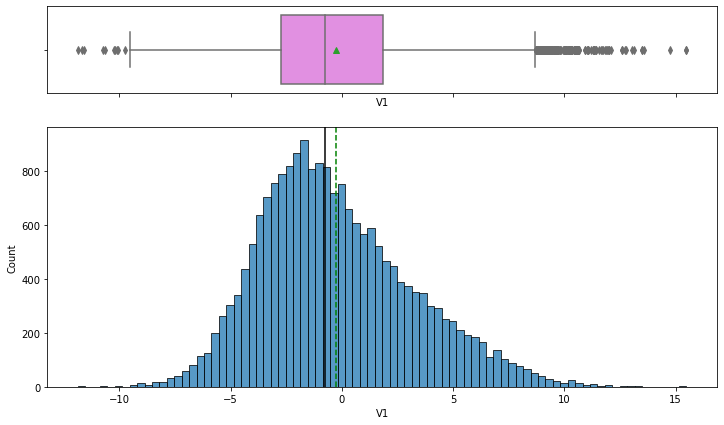

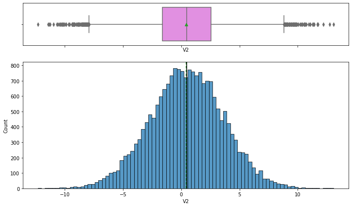

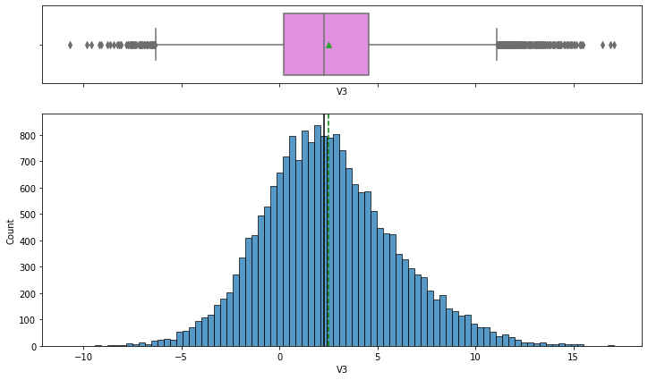

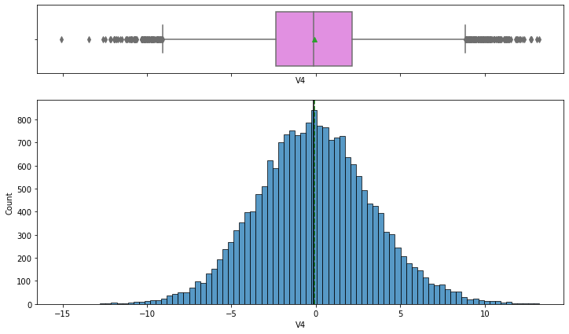

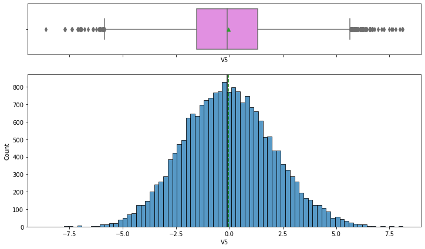

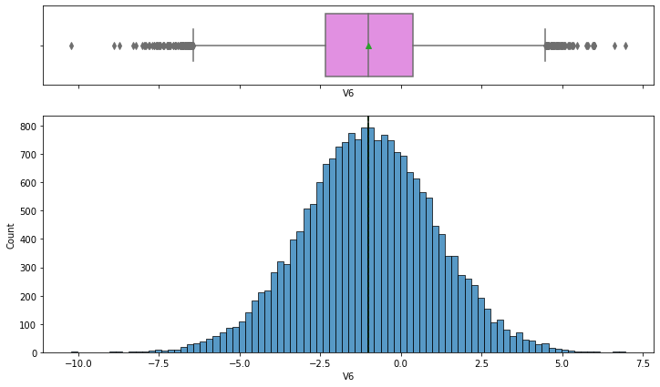

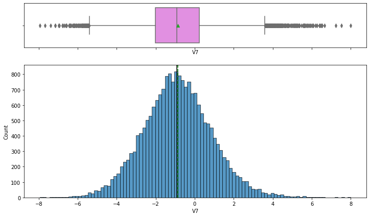

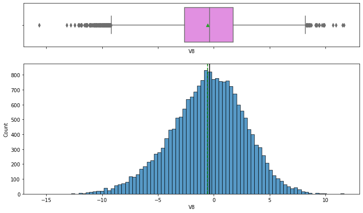

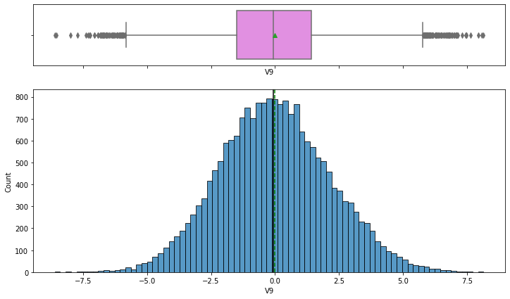

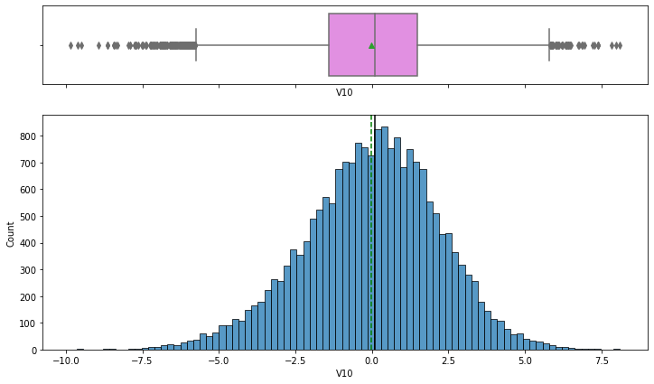

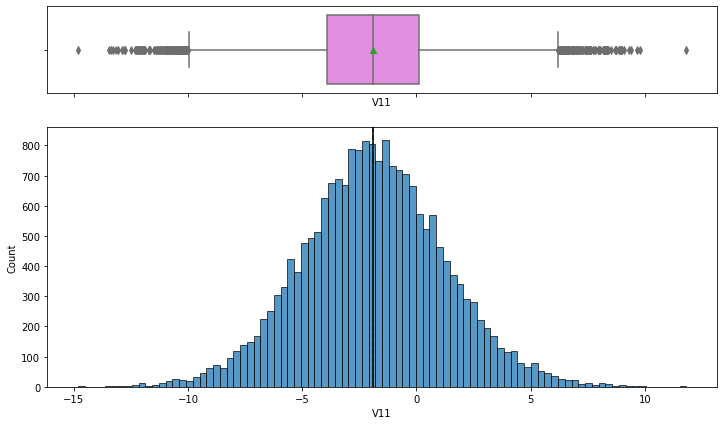

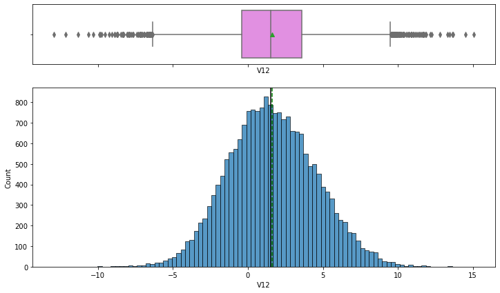

[29 more figures not shown]

```python
for feature in df.columns:
    histogram_boxplot(data, feature, figsize=(12, 7), kde=False, bins=None)
```

## Data Pre-processing

**Looking at the class distribution in train and test data set.**

```python
data["Target"].value_counts(1)
```

```
0   0.944
1   0.056
Name: Target, dtype: float64
```

```python
data_test["Target"].value_counts(1)
```

```
0   0.945
1   0.056
Name: Target, dtype: float64
```

- Class is similarly distributed between training and test dataset.

**Splitting the training dataset into training and validation data.**

```python
# separating the independent and dependent variables
X = data.drop(["Target"], axis=1)
y = data["Target"]
```

```python
# adding a contstant to X variable
X = add_constant(X)
```

```python
X_test = add_constant(X_test)
```

```python
X_train, X_val, y_train, y_val = train_test_split(
    X, y, test_size=0.5, random_state=0, stratify=y
)
```

```python
print(X_train.shape)
print(X_test.shape)
print(X_val.shape)
```

```
(10000, 41)
(5000, 41)
(10000, 41)
```

```python
y.head()
```

```
0    0
1    0
2    0
3    0
4    0
Name: Target, dtype: int64
```

```python
# separating the independent and dependent variables in test data
X_test = data_test.drop(["Target"], axis=1)
y_test = data_test["Target"]
```

- **Imputing the missing values in Training and validation dataset.**
- **We will also impute the missing value in test dataset at the same time.**

```python
imp_median = SimpleImputer(missing_values=np.nan, strategy="median")

# fit the imputer on train data and transform the train data
X_train["V1"] = imp_median.fit_transform(X_train[["V1"]])
X_train["V2"] = imp_median.fit_transform(X_train[["V2"]])
```

```python
# transform the validation and test data using the imputer fit on train data
X_val["V1"] = imp_median.transform(X_val[["V1"]])
X_val["V2"] = imp_median.transform(X_val[["V2"]])

X_test["V1"] = imp_median.transform(X_test[["V1"]])
X_test["V2"] = imp_median.transform(X_test[["V2"]])
```

```python
print("Target value ratio in y")
print(y.value_counts(1))
print("*" * 80)
print("Target value ratio in y_train")
print(y_train.value_counts(1))
print("*" * 80)
print("Target value ratio in y_val")
print(y_val.value_counts(1))
print("*" * 80)
print("Target value ratio in y_test")
print(y_test.value_counts(1))
print("*" * 80)
```

```
Target value ratio in y
0   0.945
1   0.056
Name: Target, dtype: float64
Target value ratio in y_train
0   0.945
1   0.056
Name: Target, dtype: float64
Target value ratio in y_val
0   0.945
1   0.056
Name: Target, dtype: float64
Target value ratio in y_test
0   0.944
1   0.056
Name: Target, dtype: float64
```

- Target value ratio is similarly distributed among all datasets.

## Model Building

### Model evaluation criterion

The nature of predictions made by the classification model will translate as follows:

- True positives (TP) are failures correctly predicted by the model.
- False negatives (FN) are real failures in a generator where there is no detection by model.
- False positives (FP) are failure detections in a generator where there is no failure.

### Which metric to optimize?

- We need to choose the metric which will ensure that the maximum number of generator failures are predicted correctly by the model.
- We would want Recall to be maximized as greater the Recall, the higher the chances of minimizing false negatives.
- We want to minimize false negatives because if a model predicts that a machine will have no failure when there will be a failure, it will increase the maintenance cost.

**Let's define a function to output different metrics (including recall) on the train and test set and a function to show confusion matrix so that we do not have to use the same code repetitively while evaluating models.**

```python
# defining a function to compute different metrics to check performance of a classification model built using sklearn
def model_performance_classification_sklearn(model, predictors, target):
    """
    Function to compute different metrics to check classification model performance

    model: classifier
    predictors: independent variables
    target: dependent variable
    """

    # predicting using the independent variables
    pred = model.predict(predictors)

    acc = accuracy_score(target, pred)  # to compute Accuracy
    recall = recall_score(target, pred)  # to compute Recall
    precision = precision_score(target, pred)  # to compute Precision
    f1 = f1_score(target, pred)  # to compute F1-score

    # creating a dataframe of metrics
    df_perf = pd.DataFrame(
        {"Accuracy": acc, "Recall": recall, "Precision": precision, "F1": f1},
        index=[0],
    )

    return df_perf
```

```python
def confusion_matrix_sklearn(model, predictors, target):
    """
    To plot the confusion_matrix with percentages

    model: classifier
    predictors: independent variables
    target: dependent variable
    """
    y_pred = model.predict(predictors)
    cm = confusion_matrix(target, y_pred)
    labels = np.asarray(
        [
            ["{0:0.0f}".format(item) + "\n{0:.2%}".format(item / cm.flatten().sum())]
            for item in cm.flatten()
        ]
    ).reshape(2, 2)

    plt.figure(figsize=(6, 4))
    sns.heatmap(cm, annot=labels, fmt="")
    plt.ylabel("True label")
    plt.xlabel("Predicted label")
```

### Defining scorer to be used for cross-validation and hyperparameter tuning

- We want to reduce false negatives and will try to maximize "Recall".
- To maximize Recall, we can use Recall as a **scorer** in cross-validation and hyperparameter tuning.

```python
# Type of scoring used to compare parameter combinations
scorer = metrics.make_scorer(metrics.recall_score)
```

### Model Building with original data

**Building models with original data**

```python
%%time

models = []  # Empty list to store all the models

# Appending models into the list
models.append(("logistic_regression", LogisticRegression(random_state=1)))
models.append(("dtree", DecisionTreeClassifier(random_state=1)))
models.append(("rf", RandomForestClassifier(random_state=1)))
models.append(("adaboost", AdaBoostClassifier(random_state=1)))
models.append(("gradientboost", GradientBoostingClassifier(random_state=1)))
models.append(("bagging", BaggingClassifier(random_state=1)))


results1 = []  # Empty list to store all model's CV scores
names = []  # Empty list to store name of the models


# loop through all models to get the mean cross validated score
print("\n" "Cross-Validation Cost:" "\n")

for name, model in models:
    kfold = StratifiedKFold(
        n_splits=5, shuffle=True, random_state=1
    )  # Setting number of splits equal to 5
    cv_result = cross_val_score(
        estimator=model, X=X_train, y=y_train, scoring=scorer, cv=kfold
    )
    results1.append(cv_result)
    names.append(name)
    print("{}: {}".format(name, cv_result.mean()))

print("\n" "Validation Performance:" "\n")

for name, model in models:
    model.fit(X_train, y_train)
    scores = recall_score(y_val, model.predict(X_val))
    print("{}: {}".format(name, scores))
```

```
Cross-Validation Cost:

logistic_regression: 0.4936936936936937
dtree: 0.7099099099099099
rf: 0.6756756756756758
adaboost: 0.5927927927927928
gradientboost: 0.6972972972972974
bagging: 0.6918918918918918

Validation Performance:

logistic_regression: 0.4954954954954955
dtree: 0.7009009009009008
rf: 0.7153153153153153
adaboost: 0.6126126126126126
gradientboost: 0.7261261261261261
bagging: 0.69009009009009
```

### Model Building with Oversampled data

```python
# Synthetic Minority Over Sampling Technique
sm = SMOTE(sampling_strategy=1, k_neighbors=5, random_state=1)
X_train_over, y_train_over = sm.fit_resample(X_train, y_train)

print("Before OverSampling, counts of label '1': {}".format(sum(y_train == 1)))
print("Before OverSampling, counts of label '0': {} \n".format(sum(y_train == 0)))

print("After OverSampling, counts of label '1': {}".format(sum(y_train_over == 1)))
print("After OverSampling, counts of label '0': {} \n".format(sum(y_train_over == 0)))
```

```
Before OverSampling, counts of label '1': 555
Before OverSampling, counts of label '0': 9445

After OverSampling, counts of label '1': 9445
After OverSampling, counts of label '0': 9445
```

```python
%%time

models = []  # Empty list to store all the models

# Appending models into the list
models.append(("logistic_regression", LogisticRegression(random_state=1)))
models.append(("dtree", DecisionTreeClassifier(random_state=1)))
models.append(("rf", RandomForestClassifier(random_state=1)))
models.append(("adaboost", AdaBoostClassifier(random_state=1)))
models.append(("gradientboost", GradientBoostingClassifier(random_state=1)))
models.append(("bagging", BaggingClassifier(random_state=1)))


results2 = []  # Empty list to store all model's CV scores
names = []  # Empty list to store name of the models


# loop through all models to get the mean cross validated score
print("\n" "Cross-Validation Cost:" "\n")

for name, model in models:
    kfold = StratifiedKFold(
        n_splits=5, shuffle=True, random_state=1
    )  # Setting number of splits equal to 5
    cv_result = cross_val_score(
        estimator=model, X=X_train_over, y=y_train_over, scoring=scorer, cv=kfold
    )
    results2.append(cv_result)
    names.append(name)
    print("{}: {}".format(name, cv_result.mean()))

print("\n" "Validation Performance:" "\n")

for name, model in models:
    model.fit(X_train, y_train)
    scores = recall_score(y_val, model.predict(X_val))
    print("{}: {}".format(name, scores))
```

```
Cross-Validation Cost:

logistic_regression: 0.8791953414505029
dtree: 0.9685547908946534
rf: 0.9853890947591317
adaboost: 0.8961355214399154
gradientboost: 0.9310746426680783
bagging: 0.9769190047644256

Validation Performance:

logistic_regression: 0.4954954954954955
dtree: 0.7009009009009008
rf: 0.7153153153153153
adaboost: 0.6126126126126126
gradientboost: 0.7261261261261261
bagging: 0.69009009009009
```

### Model Building with Undersampled data

```python
# Random undersampler for under sampling the data
rus = RandomUnderSampler(random_state=1, sampling_strategy=1)
X_train_un, y_train_un = rus.fit_resample(X_train, y_train)

print("Before UnderSampling, counts of label '1': {}".format(sum(y_train == 1)))
print("Before UnderSampling, counts of label '0': {} \n".format(sum(y_train == 0)))

print("After UnderSampling, counts of label '1': {}".format(sum(y_train_un == 1)))
print("After UnderSampling, counts of label '0': {} \n".format(sum(y_train_un == 0)))
```

```
Before UnderSampling, counts of label '1': 555
Before UnderSampling, counts of label '0': 9445

After UnderSampling, counts of label '1': 555
After UnderSampling, counts of label '0': 555
```

```python
%%time

models = []  # Empty list to store all the models

# Appending models into the list
models.append(("logistic_regression", LogisticRegression(random_state=1)))
models.append(("dtree", DecisionTreeClassifier(random_state=1)))
models.append(("rf", RandomForestClassifier(random_state=1)))
models.append(("adaboost", AdaBoostClassifier(random_state=1)))
models.append(("gradientboost", GradientBoostingClassifier(random_state=1)))
models.append(("bagging", BaggingClassifier(random_state=1)))


results3 = []  # Empty list to store all model's CV scores
names = []  # Empty list to store name of the models


# loop through all models to get the mean cross validated score
print("\n" "Cross-Validation Cost:" "\n")

for name, model in models:
    kfold = StratifiedKFold(
        n_splits=5, shuffle=True, random_state=1
    )  # Setting number of splits equal to 5
    cv_result = cross_val_score(
        estimator=model, X=X_train_un, y=y_train_un, scoring=scorer, cv=kfold
    )
    results3.append(cv_result)
    names.append(name)
    print("{}: {}".format(name, cv_result.mean()))

print("\n" "Validation Performance:" "\n")

for name, model in models:
    model.fit(X_train, y_train)
    scores = recall_score(y_val, model.predict(X_val))
    print("{}: {}".format(name, scores))
```

```
Cross-Validation Cost:

logistic_regression: 0.8576576576576576
dtree: 0.8450450450450451
rf: 0.8954954954954955
adaboost: 0.8810810810810811
gradientboost: 0.899099099099099
bagging: 0.8702702702702702

Validation Performance:

logistic_regression: 0.4954954954954955
dtree: 0.7009009009009008
rf: 0.7153153153153153
adaboost: 0.6126126126126126
gradientboost: 0.7261261261261261
bagging: 0.69009009009009
```

```python
names
```

```
['logistic_regression', 'dtree', 'rf', 'adaboost', 'gradientboost', 'bagging']
```

## HyperparameterTuning

### Sample Parameter Grids

**Hyperparameter tuning can take a long time to run, so to avoid that time complexity - you can use the following grids, wherever required.**

- For Gradient Boosting:

param_grid = { "n_estimators": np.arange(100,150,25), "learning_rate": [0.2, 0.05, 1], "subsample":[0.5,0.7], "max_features":[0.5,0.7] }

- For Adaboost:

param_grid = { "n_estimators": [100, 150, 200], "learning_rate": [0.2, 0.05], "base_estimator": [DecisionTreeClassifier(max_depth=1, random_state=1), DecisionTreeClassifier(max_depth=2, random_state=1), DecisionTreeClassifier(max_depth=3, random_state=1), ] }

- For Bagging Classifier:

param_grid = { 'max_samples': [0.8,0.9,1], 'max_features': [0.7,0.8,0.9], 'n_estimators' : [30,50,70], }

- For Random Forest:

param_grid = { "n_estimators": [200,250,300], "min_samples_leaf": np.arange(1, 4), "max_features": [np.arange(0.3, 0.6, 0.1),'sqrt'], "max_samples": np.arange(0.4, 0.7, 0.1) }

- For Decision Trees:

param_grid = { 'max_depth': np.arange(2,6), 'min_samples_leaf': [1, 4, 7], 'max_leaf_nodes' : [10, 15], 'min_impurity_decrease': [0.0001,0.001] }

- For Logistic Regression:

param_grid = {'C': np.arange(0.1,1.1,0.1)}

- For XGBoost:

param_grid={ 'n_estimators': [150, 200, 250], 'scale_pos_weight': [5,10], 'learning_rate': [0.1,0.2], 'gamma': [0,3,5], 'subsample': [0.8,0.9] }

### Tuning with Hyperparameters

### Tuning original dataset with Decision Tree

```python
# Choose the type of classifier.
estimator = DecisionTreeClassifier(random_state=1, class_weight="balanced")

# Grid of parameters to choose from
parameters = {
    "max_depth": np.arange(2, 20),
    "min_samples_leaf": [1, 2, 5, 7],
    "max_leaf_nodes": [5, 10, 15],
    "min_impurity_decrease": [0.0001, 0.001],
}

# Run the grid search
grid_obj = RandomizedSearchCV(estimator, parameters, scoring=scorer, cv=5)
grid_obj = grid_obj.fit(X_train, y_train)

# Set the clf to the best combination of parameters
estimator = grid_obj.best_estimator_

# Fit the best algorithm to the data.
estimator.fit(X_train, y_train)
```

```
DecisionTreeClassifier(class_weight='balanced', max_depth=19, max_leaf_nodes=15,
                       min_impurity_decrease=0.001, random_state=1)
```

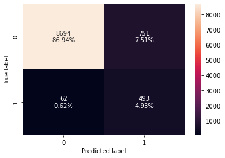

```python
confusion_matrix_sklearn(estimator, X_train, y_train)
```

#### Checking feature importance

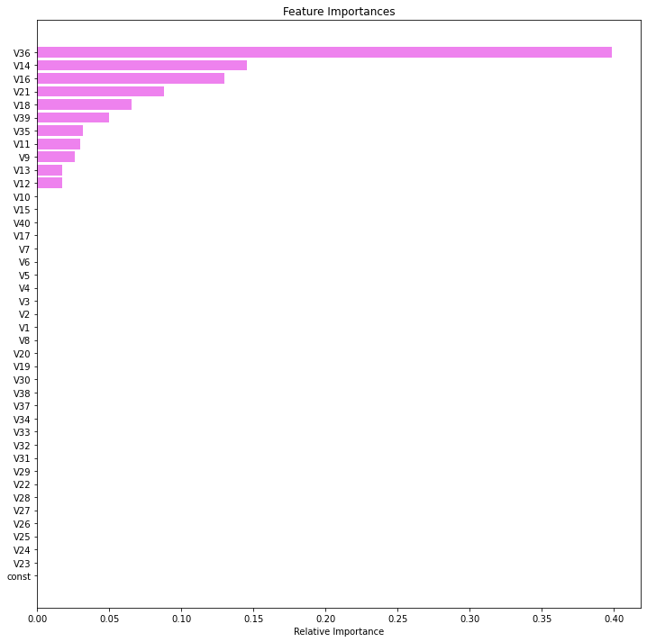

```python
feature_names = X_train.columns.to_list()
importances = estimator.feature_importances_
indices = np.argsort(importances)

plt.figure(figsize=(12, 12))
plt.title("Feature Importances")
plt.barh(range(len(indices)), importances[indices], color="violet", align="center")
plt.yticks(range(len(indices)), [feature_names[i] for i in indices])
plt.xlabel("Relative Importance")
plt.show()
```

```python
dtree_estmodel_perf_train = model_performance_classification_sklearn(
    estimator, X_train, y_train
)
print("Training performance \n", dtree_estmodel_perf_train)
```

```
Training performance
    Accuracy  Recall  Precision    F1
0     0.919   0.888      0.396 0.548
```

### Tuning Oversampled data with decision tree

```python
estimator_dtree_over = DecisionTreeClassifier(random_state=1, class_weight="balanced")

# Grid of parameters to choose from
parameters = {
    "max_depth": np.arange(2, 20),
    "min_samples_leaf": [1, 2, 5, 7],
    "max_leaf_nodes": [5, 10, 15],
    "min_impurity_decrease": [0.0001, 0.001],
}

# Run the grid search
grid_obj = RandomizedSearchCV(estimator_dtree_over, parameters, scoring=scorer, cv=5)
grid_obj = grid_obj.fit(X_train_over, y_train_over)

# Set the clf to the best combination of parameters
estimator_dtree_over = grid_obj.best_estimator_

# Fit the best algorithm to the data.
estimator_dtree_over.fit(X_train_over, y_train_over)
```

```
DecisionTreeClassifier(class_weight='balanced', max_depth=9, max_leaf_nodes=15,
                       min_impurity_decrease=0.001, min_samples_leaf=7,
                       random_state=1)
```

**Building feature importance**

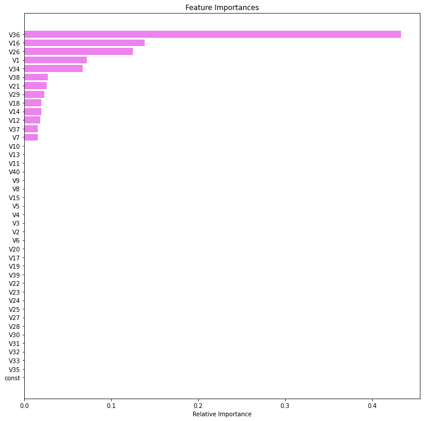

```python
feature_names = X_train_over.columns.to_list()
importances = estimator_dtree_over.feature_importances_
indices = np.argsort(importances)

plt.figure(figsize=(12, 12))
plt.title("Feature Importances")
plt.barh(range(len(indices)), importances[indices], color="violet", align="center")
plt.yticks(range(len(indices)), [feature_names[i] for i in indices])
plt.xlabel("Relative Importance")
plt.show()
```

**Building confusion matrix**

[figure not shown]

```python
confusion_matrix_sklearn(estimator_dtree_over, X_train_over, y_train_over)
```

**Checking score**

```python
dtree_est_over_perf_train = model_performance_classification_sklearn(
    estimator_dtree_over, X_train_over, y_train_over
)
print("Training performance \n", dtree_est_over_perf_train)
```

[output not shown]

### Tuning undersampled data with decision tree

```python
estimator_dtree_un = DecisionTreeClassifier(random_state=1, class_weight="balanced")

# Grid of parameters to choose from
parameters = {
    "max_depth": np.arange(2, 20),
    "min_samples_leaf": [1, 2, 5, 7],
    "max_leaf_nodes": [5, 10, 15],
    "min_impurity_decrease": [0.0001, 0.001],
}

# Run the grid search
grid_obj = RandomizedSearchCV(estimator_dtree_un, parameters, scoring=scorer, cv=5)
grid_obj = grid_obj.fit(X_train_un, y_train_un)

# Set the clf to the best combination of parameters
estimator_dtree_un = grid_obj.best_estimator_

# Fit the best algorithm to the data.
estimator_dtree_un.fit(X_train_un, y_train_un)

dtree_est_un_perf_train = model_performance_classification_sklearn(
    estimator_dtree_un, X_train_un, y_train_un
)
print("Training performance \n", dtree_est_un_perf_train)
```

```
Training performance
    Accuracy  Recall  Precision    F1
0     0.914   0.854      0.971 0.909
```

**Checking the feature importance**

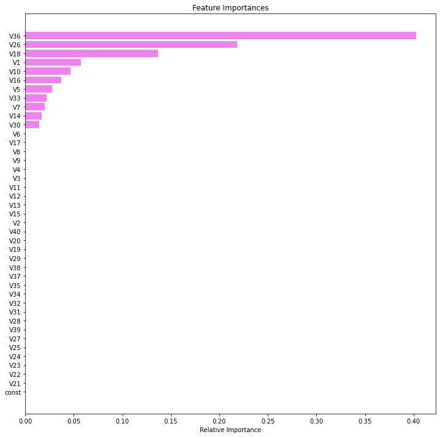

```python
feature_names = X_train.columns.to_list()
importances = estimator_dtree_un.feature_importances_
indices = np.argsort(importances)

plt.figure(figsize=(12, 12))
plt.title("Feature Importances")
plt.barh(range(len(indices)), importances[indices], color="violet", align="center")
plt.yticks(range(len(indices)), [feature_names[i] for i in indices])
plt.xlabel("Relative Importance")
plt.show()
```

**Building confusion matrix**

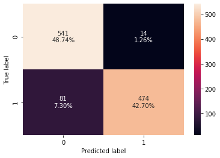

```python
confusion_matrix_sklearn(estimator_dtree_un, X_train_un, y_train_un)
```

### Tuning original data with Random Forest

```python
rf_estimator_tuned = RandomForestClassifier(random_state=1)

# creating parameters
parameters = {
    "n_estimators": [200, 250, 300],
    "min_samples_leaf": np.arange(1, 4),
    "max_features": [np.arange(0.3, 0.6, 0.1), "sqrt"],
    "max_samples": np.arange(0.4, 0.7, 0.1),
}

# Run the grid search
grid_obj = RandomizedSearchCV(rf_estimator_tuned, parameters, scoring=scorer, cv=5)
grid_obj = grid_obj.fit(X_train, y_train)

# Set the clf to the best combination of parameters
rf_estimator_tuned = grid_obj.best_estimator_

# Fit the best algorithm to the data.
rf_estimator_tuned.fit(X_train, y_train)

rf_est_perf_train = model_performance_classification_sklearn(
    rf_estimator_tuned, X_train, y_train
)
print("Training performance \n", rf_est_perf_train)
```

```
Training performance
    Accuracy  Recall  Precision    F1
0     0.990   0.816      1.000 0.899
```

#### Checking feature importance

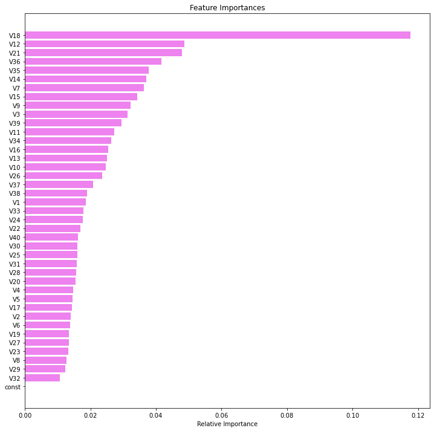

```python
feature_names = X_train.columns.to_list()
importances = rf_estimator_tuned.feature_importances_
indices = np.argsort(importances)

plt.figure(figsize=(12, 12))
plt.title("Feature Importances")
plt.barh(range(len(indices)), importances[indices], color="violet", align="center")
plt.yticks(range(len(indices)), [feature_names[i] for i in indices])
plt.xlabel("Relative Importance")
plt.show()
```

[figure not shown]

```python
confusion_matrix_sklearn(estimator_dtree_un, X_train_un, y_train_un)
```

### Tuning oversampled data with random forest

```python
rf_estimator_over_tuned = RandomForestClassifier(random_state=1)

# creating parameters
parameters = {
    "n_estimators": [300],
    "min_samples_leaf": np.arange(1, 4),
    "max_features": [np.arange(0.3, 0.6, 0.1), "sqrt"],
    "max_samples": [0.6],
}

# Run the grid search
grid_obj = RandomizedSearchCV(rf_estimator_over_tuned, parameters, scoring=scorer, cv=5)
grid_obj = grid_obj.fit(X_train_over, y_train_over)

# Set the clf to the best combination of parameters
rf_estimator_over_tuned = grid_obj.best_estimator_

# Fit the best algorithm to the data.
rf_estimator_over_tuned.fit(X_train_over, y_train_over)
```

```
RandomForestClassifier(max_features='sqrt', max_samples=0.6, n_estimators=300,
                       random_state=1)
```

**Checking score**

```python
rf_est_over_perf_train = model_performance_classification_sklearn(
    rf_estimator_over_tuned, X_train_over, y_train_over
)
print("Training performance \n", rf_est_over_perf_train)
```

```
Training performance
    Accuracy  Recall  Precision    F1
0     1.000   1.000      1.000 1.000
```

**Building feature importance**

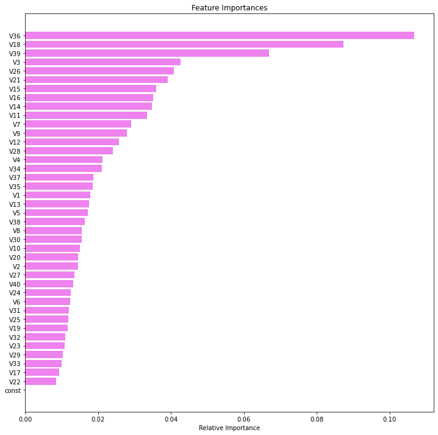

```python
feature_names = X_train_over.columns.to_list()
importances = rf_estimator_over_tuned.feature_importances_
indices = np.argsort(importances)

plt.figure(figsize=(12, 12))
plt.title("Feature Importances")
plt.barh(range(len(indices)), importances[indices], color="violet", align="center")
plt.yticks(range(len(indices)), [feature_names[i] for i in indices])
plt.xlabel("Relative Importance")
plt.show()
```

**Building confusion matrix**

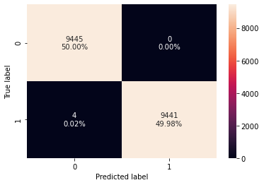

```python
confusion_matrix_sklearn(rf_estimator_over_tuned, X_train_over, y_train_over)
```

### Tuning undersampled data with random forest

```python
rf_estimator_un_tuned = RandomForestClassifier(random_state=1)

# creating parameters
parameters = {
    "n_estimators": [200, 250, 300],
    "min_samples_leaf": np.arange(1, 4),
    "max_features": [np.arange(0.3, 0.6, 0.1), "sqrt"],
    "max_samples": np.arange(0.4, 0.7, 0.1),
}

# Run the grid search
grid_obj = RandomizedSearchCV(rf_estimator_un_tuned, parameters, scoring=scorer, cv=5)
grid_obj = grid_obj.fit(X_train_un, y_train_un)

# Set the clf to the best combination of parameters
rf_estimator_un_tuned = grid_obj.best_estimator_

# Fit the best algorithm to the data.
rf_estimator_un_tuned.fit(X_train_un, y_train_un)
```

```
RandomForestClassifier(max_features='sqrt', max_samples=0.5, min_samples_leaf=2,
                       n_estimators=200, random_state=1)
```

**Checking score**

```python
rf_est_over_perf_train = model_performance_classification_sklearn(
    rf_estimator_over_tuned, X_train_over, y_train_over
)
print("Training performance \n", rf_est_over_perf_train)
```

```
Training performance
    Accuracy  Recall  Precision    F1
0     1.000   1.000      1.000 1.000
```

**Building feature importance**

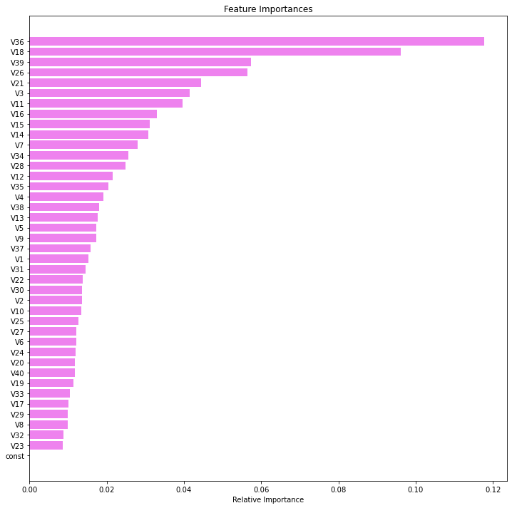

```python
feature_names = X_train_un.columns.to_list()
importances = rf_estimator_un_tuned.feature_importances_
indices = np.argsort(importances)

plt.figure(figsize=(12, 12))
plt.title("Feature Importances")
plt.barh(range(len(indices)), importances[indices], color="violet", align="center")
plt.yticks(range(len(indices)), [feature_names[i] for i in indices])
plt.xlabel("Relative Importance")
plt.show()
```

**Building confusion matrix**

[figure not shown]

```python
confusion_matrix_sklearn(rf_estimator_un_tuned, X_train_un, y_train_un)
```

### Tuning original dataset with Adaboost

```python
abc_tuned = AdaBoostClassifier(random_state=1)

# Grid of parameters to choose from

parameters = {
    "n_estimators": [100, 150, 200],
    "learning_rate": [0.2, 0.05],
    "base_estimator": [
        DecisionTreeClassifier(max_depth=1, random_state=1),
        DecisionTreeClassifier(max_depth=2, random_state=1),
        DecisionTreeClassifier(max_depth=3, random_state=1),
    ],
}

# Run the grid search
grid_obj = RandomizedSearchCV(abc_tuned, parameters, scoring=acc_scorer, cv=5)
grid_obj = grid_obj.fit(X_train, y_train)

# Set the clf to the best combination of parameters
abc_tuned = grid_obj.best_estimator_

# Fit the best algorithm to the data.
abc_tuned.fit(X_train, y_train)
```

```
AdaBoostClassifier(base_estimator=DecisionTreeClassifier(max_depth=3,
                                                         random_state=1),
                   learning_rate=0.2, n_estimators=200, random_state=1)
```

**Checking score**

```python
abc_tuned_perf_train = model_performance_classification_sklearn(
    abc_tuned, X_train, y_train
)
print("Training performance \n", abc_tuned_perf_train)
```

```
Training performance
    Accuracy  Recall  Precision    F1
0     0.927   0.993      0.430 0.601
```

**Building feature importance**

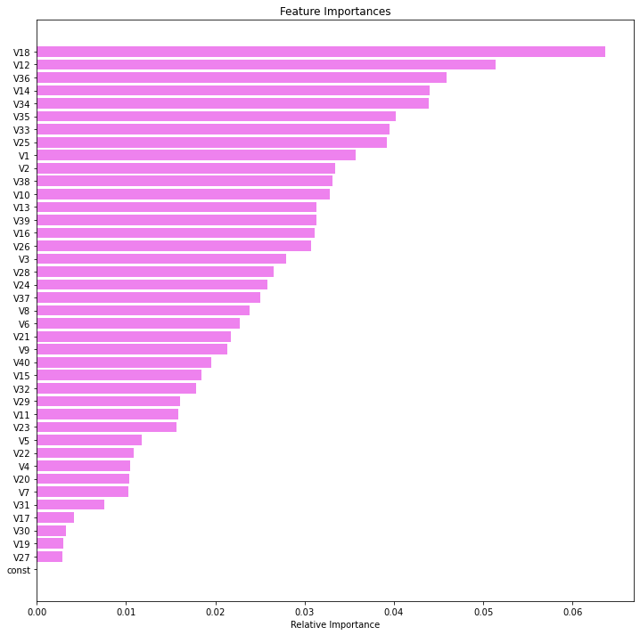

```python
feature_names = X_train.columns.to_list()
importances = abc_tuned.feature_importances_
indices = np.argsort(importances)

plt.figure(figsize=(12, 12))
plt.title("Feature Importances")
plt.barh(range(len(indices)), importances[indices], color="violet", align="center")
plt.yticks(range(len(indices)), [feature_names[i] for i in indices])
plt.xlabel("Relative Importance")
plt.show()
```

**Building confusion matrix**

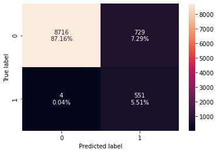

```python
confusion_matrix_sklearn(abc_tuned, X_train, y_train)
```

### Tuning oversampled data with adaboost

```python
abc_tuned_over = AdaBoostClassifier(random_state=1)

# Grid of parameters to choose from

parameters = {
    "n_estimators": [200],
    "learning_rate": [0.2],
    "base_estimator": [DecisionTreeClassifier(max_depth=3, random_state=1),],
}

# Run the grid search
grid_obj = RandomizedSearchCV(abc_tuned_over, parameters, scoring=acc_scorer, cv=5)
grid_obj = grid_obj.fit(X_train_over, y_train_over)

# Set the clf to the best combination of parameters
abc_tuned = grid_obj.best_estimator_

# Fit the best algorithm to the data.
abc_tuned_over.fit(X_train_over, y_train_over)
```

```
AdaBoostClassifier(random_state=1)
```

**Checking score**

```python
abc_tuned_over_perf_train = model_performance_classification_sklearn(
    abc_tuned_over, X_train_over, y_train_over
)
print("Training performance \n", abc_tuned_over_perf_train)
```

```
Training performance
    Accuracy  Recall  Precision    F1
0     0.908   0.893      0.919 0.906
```

**Building Feature importance**

```python
feature_names = X_train_over.columns.to_list()
importances = abc_tuned_over.feature_importances_
indices = np.argsort(importances)

plt.figure(figsize=(12, 12))
plt.title("Feature Importances")
plt.barh(range(len(indices)), importances[indices], color="violet", align="center")
plt.yticks(range(len(indices)), [feature_names[i] for i in indices])
plt.xlabel("Relative Importance")
plt.show()
```

[output not shown]

**Building confusion matrix**

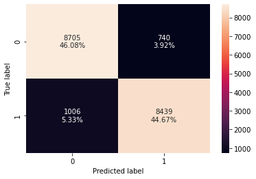

```python
confusion_matrix_sklearn(abc_tuned_over, X_train_over, y_train_over)
```

### Tuning undersampled data with adaboost

```python
abc_tuned_un = AdaBoostClassifier(random_state=1)

# Grid of parameters to choose from

parameters = {
    "n_estimators": [200],
    "learning_rate": [0.2],
    "base_estimator": [DecisionTreeClassifier(max_depth=3, random_state=1),],
}

# Run the grid search
grid_obj = RandomizedSearchCV(abc_tuned_un, parameters, scoring=acc_scorer, cv=5)
grid_obj = grid_obj.fit(X_train_un, y_train_un)

# Set the clf to the best combination of parameters
abc_tuned = grid_obj.best_estimator_

# Fit the best algorithm to the data.
abc_tuned_un.fit(X_train_un, y_train_un)
```

```
AdaBoostClassifier(random_state=1)
```

**Checking score**

```python
abc_tuned_un_perf_train = model_performance_classification_sklearn(
    abc_tuned_un, X_train_un, y_train_un
)
print("Training performance \n", abc_tuned_un_perf_train)
```

```
Training performance
    Accuracy  Recall  Precision    F1
0     0.938   0.919      0.955 0.937
```

**Building feature importance**

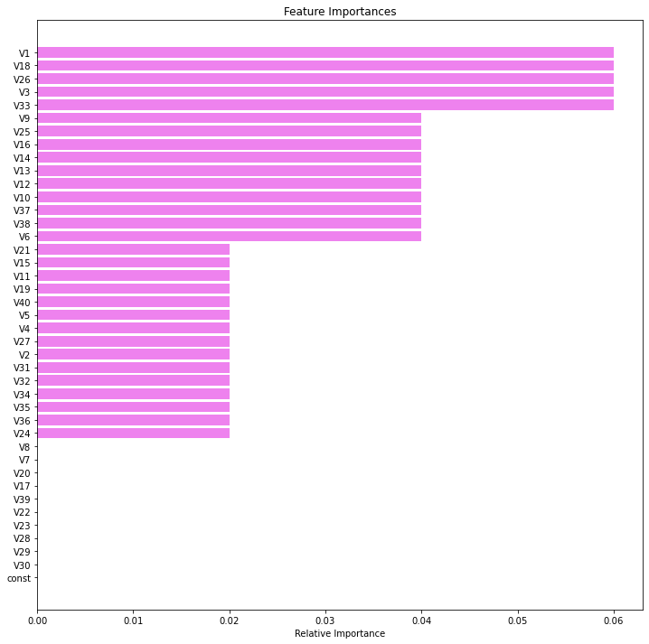

```python
feature_names = X_train_un.columns.to_list()
importances = abc_tuned_un.feature_importances_
indices = np.argsort(importances)

plt.figure(figsize=(12, 12))
plt.title("Feature Importances")
plt.barh(range(len(indices)), importances[indices], color="violet", align="center")
plt.yticks(range(len(indices)), [feature_names[i] for i in indices])
plt.xlabel("Relative Importance")
plt.show()
```

**Building confusion matrix**

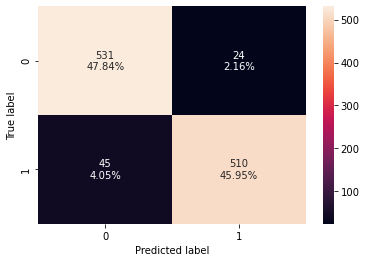

```python
confusion_matrix_sklearn(abc_tuned_un, X_train_un, y_train_un)
```

### Tuning original dataset with Gradient boosting

```python
gbc_tuned = GradientBoostingClassifier(
    init=AdaBoostClassifier(random_state=1), random_state=1
)

# Grid of parameters to choose from
## add from article
parameters = {
    "n_estimators": np.arange(100, 150, 25),
    "learning_rate": [0.2, 0.05, 1],
    "subsample": [0.5, 0.7],
    "max_features": [0.5, 0.7],
}

# Run the grid search
grid_obj = RandomizedSearchCV(gbc_tuned, parameters, scoring=acc_scorer, cv=5)
grid_obj = grid_obj.fit(X_train, y_train)

# Set the clf to the best combination of parameters
gbc_tuned = grid_obj.best_estimator_

# Fit the best algorithm to the data.
gbc_tuned.fit(X_train, y_train)
```

```
GradientBoostingClassifier(init=AdaBoostClassifier(random_state=1),
                           learning_rate=0.2, max_features=0.5, random_state=1,
                           subsample=0.7)
```

**Checking score**

```python
gbc_tuned_perf_train = model_performance_classification_sklearn(
    gbc_tuned, X_train, y_train
)
print("Training performance \n", gbc_tuned_perf_train)
```

```
Training performance
    Accuracy  Recall  Precision    F1
0     0.995   0.914      0.988 0.949
```

**Building Feature importance**

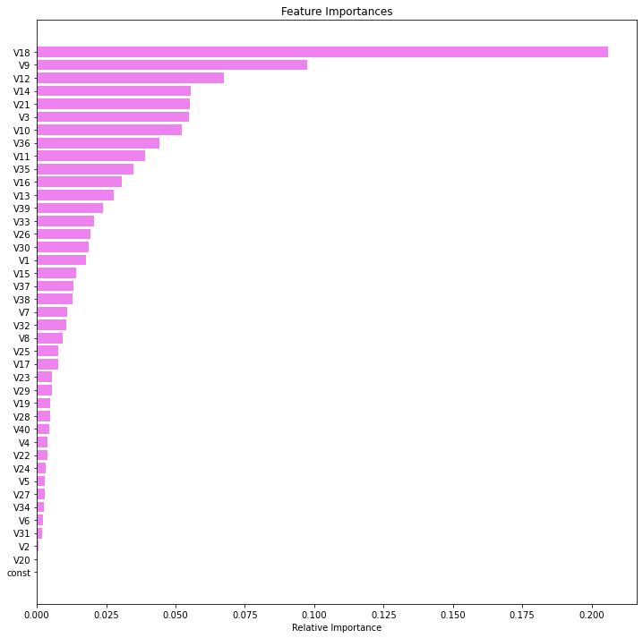

```python
feature_names = X_train.columns.to_list()
importances = gbc_tuned.feature_importances_
indices = np.argsort(importances)

plt.figure(figsize=(12, 12))
plt.title("Feature Importances")
plt.barh(range(len(indices)), importances[indices], color="violet", align="center")
plt.yticks(range(len(indices)), [feature_names[i] for i in indices])
plt.xlabel("Relative Importance")
plt.show()
```

**Building confusion matrix**

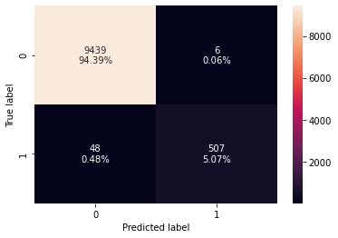

```python
confusion_matrix_sklearn(gbc_tuned, X_train, y_train)
```

### Tuning oversampled data with Gradient boosting

```python
gbc_tuned_over = GradientBoostingClassifier(
    init=AdaBoostClassifier(random_state=1), random_state=1
)

# Grid of parameters to choose from
## add from article
parameters = {
    "n_estimators": np.arange(100, 150, 25),
    "learning_rate": [0.2],
    "subsample": [0.7],
    "max_features": [0.5],
}

# Run the grid search
grid_obj = RandomizedSearchCV(gbc_tuned_over, parameters, scoring=acc_scorer, cv=5)
grid_obj = grid_obj.fit(X_train_over, y_train_over)

# Set the clf to the best combination of parameters
gbc_tuned_over = grid_obj.best_estimator_

# Fit the best algorithm to the data.
gbc_tuned_over.fit(X_train_over, y_train_over)
```

```
GradientBoostingClassifier(init=AdaBoostClassifier(random_state=1),
                           learning_rate=0.2, max_features=0.5,
                           n_estimators=125, random_state=1, subsample=0.7)
```

**Checking score**

```python
gbc_tuned_over_perf_train = model_performance_classification_sklearn(
    gbc_tuned_over, X_train_over, y_train_over
)
print("Training performance \n", gbc_tuned_over_perf_train)
```

```
Training performance
    Accuracy  Recall  Precision    F1
0     0.981   0.975      0.987 0.981
```

### Tuning undersampled data with gradient boosting

```python
gbc_tuned_un = GradientBoostingClassifier(
    init=AdaBoostClassifier(random_state=1), random_state=1
)

# Grid of parameters to choose from
## add from article
parameters = {
    "n_estimators": [125],
    "learning_rate": [0.2],
    "subsample": [0.7],
    "max_features": [0.5],
}

# Run the grid search
grid_obj = RandomizedSearchCV(gbc_tuned_un, parameters, scoring=scorer, cv=5)
grid_obj = grid_obj.fit(X_train_un, y_train_un)

# Set the clf to the best combination of parameters
gbc_tuned_un = grid_obj.best_estimator_

# Fit the best algorithm to the data.
gbc_tuned_un.fit(X_train_un, y_train_un)
```

```
GradientBoostingClassifier(init=AdaBoostClassifier(random_state=1),
                           learning_rate=0.2, max_features=0.5,
                           n_estimators=125, random_state=1, subsample=0.7)
```

**Checking score**

```python
gbc_tuned_un_perf_train = model_performance_classification_sklearn(
    gbc_tuned_un, X_train_un, y_train_un
)
print("Training performance \n", gbc_tuned_un_perf_train)
```

```
Training performance
    Accuracy  Recall  Precision    F1
0     1.000   1.000      1.000 1.000
```

### Tuning original dataset with bagging

```python
bagging_tuned = BaggingClassifier(random_state=1)

# Grid of parameters to choose from
## add from article
parameters = {
    "max_samples": [0.8, 0.9, 1],
    "max_features": [0.7, 0.8, 0.9],
    "n_estimators": [30, 50, 70],
}

# Run the grid search
grid_obj = RandomizedSearchCV(bagging_tuned, parameters, scoring=scorer, cv=5)
grid_obj = grid_obj.fit(X_train, y_train)

# Set the clf to the best combination of parameters
bagging_tuned = grid_obj.best_estimator_

# Fit the best algorithm to the data.
bagging_tuned.fit(X_train, y_train)
```

```
BaggingClassifier(max_features=0.9, max_samples=0.9, n_estimators=70,
                  random_state=1)
```

**Checking score**

```python
bagging_tuned_perf_train = model_performance_classification_sklearn(
    bagging_tuned, X_train, y_train
)
print("Training performance \n", bagging_tuned_perf_train)
```

```
Training performance
    Accuracy  Recall  Precision    F1
0     1.000   0.993      1.000 0.996
```

**Building confusion matrix**

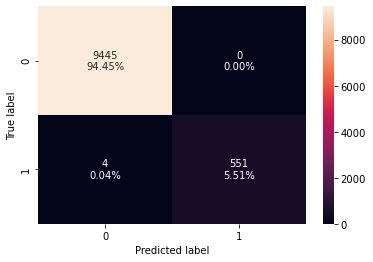

```python
confusion_matrix_sklearn(bagging_tuned, X_train, y_train)
```

### Tuning oversampled dataset with bagging

```python
bagging_tuned_over = BaggingClassifier(random_state=1)

# Grid of parameters to choose from
## add from article
parameters = {
    "max_samples": [0.9],
    "max_features": [0.9],
    "n_estimators": [70],
}

# Run the grid search
grid_obj = RandomizedSearchCV(bagging_tuned_over, parameters, scoring=scorer, cv=5)
grid_obj = grid_obj.fit(X_train_over, y_train_over)

# Set the clf to the best combination of parameters
bagging_tuned_over = grid_obj.best_estimator_

# Fit the best algorithm to the data.
bagging_tuned_over.fit(X_train_over, y_train_over)
```

```
BaggingClassifier(max_features=0.9, max_samples=0.9, n_estimators=70,
                  random_state=1)
```

**Checking score**

```python
bagging_tuned_over_perf_train = model_performance_classification_sklearn(
    bagging_tuned_un, X_train_un, y_train_un
)
print("Training performance \n", bagging_tuned_over_perf_train)
```

```
Training performance
    Accuracy  Recall  Precision    F1
0     1.000   1.000      1.000 1.000
```

### Tuning undersampled data with bagging

```python
bagging_tuned_un = BaggingClassifier(random_state=1)

# Grid of parameters to choose from
## add from article
parameters = {
    "max_samples": [0.9],
    "max_features": [0.9],
    "n_estimators": [70],
}

# Run the grid search
grid_obj = RandomizedSearchCV(bagging_tuned_un, parameters, scoring=scorer, cv=5)
grid_obj = grid_obj.fit(X_train_un, y_train_un)

# Set the clf to the best combination of parameters
bagging_tuned_un = grid_obj.best_estimator_

# Fit the best algorithm to the data.
bagging_tuned_un.fit(X_train_un, y_train_un)
```

```
BaggingClassifier(max_features=0.9, max_samples=0.9, n_estimators=70,
                  random_state=1)
```

**Checking score**

```python
bagging_tuned_un_perf_train = model_performance_classification_sklearn(
    bagging_tuned_un, X_train_un, y_train_un
)
print("Training performance \n", bagging_tuned_un_perf_train)
```

```
Training performance
    Accuracy  Recall  Precision    F1
0     1.000   1.000      1.000 1.000
```

### Validation scores on different models

```python
# Decision tree validation scores
dtree_perf_val_tuned = model_performance_classification_sklearn(estimator, X_val, y_val)
dtree_perf_val_over_tuned = model_performance_classification_sklearn(estimator_dtree_over, X_val, y_val)
dtree_perf_val_under_tuned = model_performance_classification_sklearn(estimator_dtree_un, X_val, y_val)

print("performance on original data \n", dtree_perf_val_tuned)
print("performance on oversampled data \n", dtree_perf_val_over_tuned)
print("performance on undersampled data \n", dtree_perf_val_under_tuned)
```

```
performance on original data
    Accuracy  Recall  Precision    F1
0     0.876   0.836      0.288 0.428
performance on oversampled data
    Accuracy  Recall  Precision    F1
0     0.876   0.836      0.288 0.428
performance on undersampled data
    Accuracy  Recall  Precision    F1
0     0.916   0.814      0.381 0.519
```

```python
    # Random forest validation scores
    rf_perf_val_tuned = model_performance_classification_sklearn(rf_estimator_tuned, X_val, y_val)
    rf_perf_val_over_tuned = model_performance_classification_sklearn(rf_estimator_over_tuned, X_val, y_val)
    rf_perf_val_under_tuned = model_performance_classification_sklearn(rf_estimator_un_tuned, X_val, y_val)

print("performance on original data \n", rf_perf_val_tuned)
print("performance on oversampled data \n", rf_perf_val_over_tuned)
print("performance on undersampled data \n", rf_perf_val_under_tuned)
```

```
performance on original data
    Accuracy  Recall  Precision    F1
0     0.982   0.686      0.984 0.809
performance on oversampled data
    Accuracy  Recall  Precision    F1
0     0.987   0.854      0.903 0.878
performance on undersampled data
    Accuracy  Recall  Precision    F1
0     0.919   0.901      0.399 0.553
```

```python
#Adaboost validation scores
abc_perf_val_tuned = model_performance_classification_sklearn(abc_tuned, X_val, y_val)
abc_perf_val_over_tuned = model_performance_classification_sklearn(abc_tuned_over, X_val, y_val)
abc_perf_val_under_tuned = model_performance_classification_sklearn(abc_tuned_un, X_val, y_val)

print("performance on original data \n", abc_perf_val_tuned)
print("performance on oversampled data \n", abc_perf_val_over_tuned)
print("performance on undersampled data \n", abc_perf_val_under_tuned)
```

```
performance on original data
    Accuracy  Recall  Precision    F1
0     0.928   0.895      0.429 0.580
performance on oversampled data
    Accuracy  Recall  Precision    F1
0     0.917   0.856      0.389 0.535
performance on undersampled data
    Accuracy  Recall  Precision    F1
0     0.858   0.877      0.264 0.406
```

```python
#Gradient Boost validation scores
gbc_perf_val_tuned = model_performance_classification_sklearn(gbc_tuned, X_val, y_val)
gbc_perf_val_over_tuned = model_performance_classification_sklearn(gbc_tuned_over, X_val, y_val)
gbc_perf_val_under_tuned = model_performance_classification_sklearn(gbc_tuned_un, X_val, y_val)

print("performance on original data \n", gbc_perf_val_tuned)
print("performance on oversampled data \n", gbc_perf_val_over_tuned)
print("performance on undersampled data \n", gbc_perf_val_under_tuned)
```

```
performance on original data
    Accuracy  Recall  Precision    F1
0     0.982   0.766      0.902 0.828
performance on oversampled data
    Accuracy  Recall  Precision    F1
0     0.973   0.874      0.712 0.785
performance on undersampled data
    Accuracy  Recall  Precision    F1
0     0.913   0.906      0.382 0.537
```

```python
#Bagging validation scores
bagging_perf_val_tuned = model_performance_classification_sklearn(bagging_tuned, X_val, y_val)
bagging_perf_val_over_tuned = model_performance_classification_sklearn(bagging_tuned_over, X_val, y_val)
bagging_perf_val_under_tuned = model_performance_classification_sklearn(bagging_tuned_un, X_val, y_val)

print("performance with original data \n", bagging_perf_val_tuned)
print("performance with oversampled data \n", bagging_perf_val_over_tuned)
print("performance undersampled data \n", bagging_perf_val_under_tuned)
```

```
performance with original data
    Accuracy  Recall  Precision    F1
0     0.983   0.724      0.964 0.827
performance with oversampled data
    Accuracy  Recall  Precision    F1
0     0.979   0.816      0.805 0.810
performance undersampled data
    Accuracy  Recall  Precision    F1
0     0.918   0.895      0.394 0.548
```

## Model performance comparison and choosing the final model

```python
# comparing models on validation scores
models_val_comp_df = pd.concat(
    [
        dtree_perf_val_tuned.T,
        dtree_perf_val_over_tuned.T,
        dtree_perf_val_under_tuned.T,
        rf_perf_val_tuned.T,
        rf_perf_val_over_tuned.T,
        rf_perf_val_under_tuned.T,
        abc_perf_val_tuned.T,
        abc_perf_val_over_tuned.T,
        abc_perf_val_under_tuned.T,
        gbc_perf_val_tuned.T,
        gbc_perf_val_over_tuned.T,
        gbc_perf_val_under_tuned.T,
        bagging_perf_val_tuned.T,
        bagging_perf_val_over_tuned.T,
        bagging_perf_val_under_tuned.T,
    ],
    axis=1,
)
models_val_comp_df.columns = [
    "Decision tree tuned with original data",
    "Decision tree tuned with oversampled data",
    "Decision tree tuned with undersampled data",
    "Random forest tuned with original data",
    "Random forest tuned with oversampled data",
    "Random forest tuned with undersampled data",
    "AdaBoost classifier tuned with original data",
    "AdaBoost classifier tuned with oversampled data",
    "AdaBoost classifier tuned with undersampled data",
    "Gradient Boosting tuned with original data",
    "Gradient Boosting tuned with oversampled data",
    "Gradient Boosting tuned with undersampled data",
    "Bagging classifier tuned with original data",
    "Bagging classifier tuned with oversampled data",
    "Bagging classifier tuned with undersampled data",
]
print("Validation score performance comparison:")
models_val_comp_df
```

```
Validation score performance comparison:
```

|  | Decision tree tuned with original data | Decision tree tuned with oversampled data | Decision tree tuned with undersampled data | Random forest tuned with original data | Random forest tuned with oversampled data | Random forest tuned with undersampled data | AdaBoost classifier tuned with original data | AdaBoost classifier tuned with oversampled data | AdaBoost classifier tuned with undersampled data | Gradient Boosting tuned with original data | Gradient Boosting tuned with oversampled data | Gradient Boosting tuned with undersampled data | Bagging classifier tuned with original data | Bagging classifier tuned with oversampled data | Bagging classifier tuned with undersampled data |
| --- | --- | --- | --- | --- | --- | --- | --- | --- | --- | --- | --- | --- | --- | --- | --- |
| Accuracy | 0.876 | 0.876 | 0.916 | 0.982 | 0.987 | 0.919 | 0.928 | 0.917 | 0.858 | 0.982 | 0.973 | 0.913 | 0.983 | 0.979 | 0.918 |
| Recall | 0.836 | 0.836 | 0.814 | 0.686 | 0.854 | 0.901 | 0.895 | 0.856 | 0.877 | 0.766 | 0.874 | 0.906 | 0.724 | 0.816 | 0.895 |
| Precision | 0.288 | 0.288 | 0.381 | 0.984 | 0.903 | 0.399 | 0.429 | 0.389 | 0.264 | 0.902 | 0.712 | 0.382 | 0.964 | 0.805 | 0.394 |
| F1 | 0.428 | 0.428 | 0.519 | 0.809 | 0.878 | 0.553 | 0.580 | 0.535 | 0.406 | 0.828 | 0.785 | 0.537 | 0.827 | 0.810 | 0.548 |

- We can see Recall score by `Gradient Boosting tuned with undersampled data` is highest with **0.906** followed closely by `Random forest tuned with undersampled data` with **0.901**.

### Test set final performance

```python
# Decision tree testing scores
dtree_perf_test_tuned = model_performance_classification_sklearn(estimator, X_test, y_test)
dtree_perf_test_over_tuned = model_performance_classification_sklearn(estimator_dtree_over, X_test, y_test)
dtree_perf_test_under_tuned = model_performance_classification_sklearn(estimator_dtree_un, X_test, y_test)

# Random forest testing scores
rf_perf_test_tuned = model_performance_classification_sklearn(rf_estimator_tuned, X_test, y_test)
rf_perf_test_over_tuned = model_performance_classification_sklearn(rf_estimator_over_tuned, X_test, y_test)
rf_perf_test_under_tuned = model_performance_classification_sklearn(rf_estimator_un_tuned, X_test, y_test)

#Adaboost testing scores
abc_perf_test_tuned = model_performance_classification_sklearn(abc_tuned, X_test, y_test)
abc_perf_test_over_tuned = model_performance_classification_sklearn(abc_tuned_over, X_test, y_test)
abc_perf_test_under_tuned = model_performance_classification_sklearn(abc_tuned_un, X_test, y_test)

#Gradient Boost testing scores
gbc_perf_test_tuned = model_performance_classification_sklearn(gbc_tuned, X_test, y_test)
gbc_perf_test_over_tuned = model_performance_classification_sklearn(gbc_tuned_over, X_test, y_test)
gbc_perf_test_under_tuned = model_performance_classification_sklearn(gbc_tuned_un, X_test, y_test)

#Bagging testing scores
bagging_perf_test_tuned = model_performance_classification_sklearn(bagging_tuned, X_test, y_test)
bagging_perf_test_over_tuned = model_performance_classification_sklearn(bagging_tuned_over, X_test, y_test)
bagging_perf_test_under_tuned = model_performance_classification_sklearn(bagging_tuned_un, X_test, y_test)
```

```python
# comparing models on validation scores
models_test_comp_df = pd.concat(
    [
        dtree_perf_test_tuned.T,
        dtree_perf_test_over_tuned.T,
        dtree_perf_test_under_tuned.T,
        rf_perf_test_tuned.T,
        rf_perf_test_over_tuned.T,
        rf_perf_test_under_tuned.T,
        abc_perf_test_tuned.T,
        abc_perf_test_over_tuned.T,
        abc_perf_test_under_tuned.T,
        gbc_perf_test_tuned.T,
        gbc_perf_test_over_tuned.T,
        gbc_perf_test_under_tuned.T,
        bagging_perf_test_tuned.T,
        bagging_perf_test_over_tuned.T,
        bagging_perf_test_under_tuned.T,
    ],
    axis=1,
)
models_test_comp_df.columns = [
    "Decision tree tuned with original data",
    "Decision tree tuned with oversampled data",
    "Decision tree tuned with undersampled data",
    "Random forest tuned with original data",
    "Random forest tuned with oversampled data",
    "Random forest tuned with undersampled data",
    "AdaBoost classifier tuned with original data",
    "AdaBoost classifier tuned with oversampled data",
    "AdaBoost classifier tuned with undersampled data",
    "Gradient Boosting tuned with original data",
    "Gradient Boosting tuned with oversampled data",
    "Gradient Boosting tuned with undersampled data",
    "Bagging classifier tuned with original data",
    "Bagging classifier tuned with oversampled data",
    "Bagging classifier tuned with undersampled data",
]
print("Validation score performance comparison:")
models_test_comp_df
```

```
Validation score performance comparison:
```

|  | Decision tree tuned with original data | Decision tree tuned with oversampled data | Decision tree tuned with undersampled data | Random forest tuned with original data | Random forest tuned with oversampled data | Random forest tuned with undersampled data | AdaBoost classifier tuned with original data | AdaBoost classifier tuned with oversampled data | AdaBoost classifier tuned with undersampled data | Gradient Boosting tuned with original data | Gradient Boosting tuned with oversampled data | Gradient Boosting tuned with undersampled data | Bagging classifier tuned with original data | Bagging classifier tuned with oversampled data | Bagging classifier tuned with undersampled data |
| --- | --- | --- | --- | --- | --- | --- | --- | --- | --- | --- | --- | --- | --- | --- | --- |
| Accuracy | 0.882 | 0.882 | 0.916 | 0.977 | 0.986 | 0.915 | 0.923 | 0.912 | 0.860 | 0.980 | 0.972 | 0.914 | 0.980 | 0.979 | 0.914 |
| Recall | 0.823 | 0.823 | 0.784 | 0.596 | 0.830 | 0.879 | 0.879 | 0.844 | 0.833 | 0.716 | 0.855 | 0.876 | 0.688 | 0.787 | 0.872 |
| Precision | 0.301 | 0.301 | 0.380 | 0.988 | 0.921 | 0.389 | 0.414 | 0.377 | 0.265 | 0.906 | 0.705 | 0.385 | 0.951 | 0.825 | 0.385 |
| F1 | 0.441 | 0.441 | 0.512 | 0.743 | 0.873 | 0.540 | 0.563 | 0.521 | 0.402 | 0.800 | 0.772 | 0.535 | 0.798 | 0.806 | 0.534 |

## Pipelines to build the final model

```python
# Build pipeline
pipeline = Pipeline(
    steps=[
        ("imp", imputer),
        (
            "adaboost",
            AdaBoostClassifier(
                base_estimator=DecisionTreeClassifier(max_depth=3, random_state=1),
                learning_rate=0.2,
                n_estimators=200,
                random_state=1,
            ),
        ),
    ]
)
# Fit the model on training data
pipeline.fit(X1, y1)
```

```
Pipeline(steps=[('imp', SimpleImputer(strategy='median')),
                ('adaboost',
                 AdaBoostClassifier(base_estimator=DecisionTreeClassifier(max_depth=3,
                                                                          random_state=1),
                                    learning_rate=0.2, n_estimators=200,
                                    random_state=1))])
```

```python
# Separating target variable and other variables
X1 = data.drop(columns="Target")
Y1 = data["Target"]

X_test1 = data_test.drop(columns="Target")
y_test1 = data_test["Target"]
```

```python
# Fit the model on training data
pipeline.fit(X1, Y1)
```

```
Pipeline(steps=[('imp', SimpleImputer(strategy='median')),
                ('adaboost',
                 AdaBoostClassifier(base_estimator=DecisionTreeClassifier(max_depth=3,
                                                                          random_state=1),
                                    learning_rate=0.2, n_estimators=200,
                                    random_state=1))])
```

```python
# filling the nan values in the training data
imputer = SimpleImputer(strategy="median")
X1 = imputer.fit_transform(X1)
```

```python
# Synthetic Minority Over Sampling Technique
sm = SMOTE(sampling_strategy=1, k_neighbors=5, random_state=1)
X_over1, y_over1 = sm.fit_resample(X1, Y1)
```

```python
pipeline.fit(X1, Y1)
```

```
Pipeline(steps=[('imp', SimpleImputer(strategy='median')),
                ('adaboost',
                 AdaBoostClassifier(base_estimator=DecisionTreeClassifier(max_depth=3,
                                                                          random_state=1),
                                    learning_rate=0.2, n_estimators=200,
                                    random_state=1))])
```

```python
Pipeline_test = model_performance_classification_sklearn(pipeline, X_test1, y_test1)
Pipeline_test
```

|  | Accuracy | Recall | Precision | F1 |
| --- | --- | --- | --- | --- |
| 0 | 0.986 | 0.770 | 0.977 | 0.861 |

```python
# Build pipeline using Randforest classifier
pipeline1 = Pipeline(
    steps=[
        ("imp", imputer),
        (
            "random_forest",
            RandomForestClassifier(
                max_features="sqrt",
                max_samples=0.5,
                min_samples_leaf=2,
                n_estimators=200,
                random_state=1,
            ),
        ),
    ]
)
# Fit the model on training data
pipeline1.fit(X1, Y1)
```

```
Pipeline(steps=[('imp', SimpleImputer(strategy='median')),
                ('random_forest',
                 RandomForestClassifier(max_features='sqrt', max_samples=0.5,
                                        min_samples_leaf=2, n_estimators=200,
                                        random_state=1))])
```

```python
pipeline1.fit(X_test1, y_test1)
```

```
Pipeline(steps=[('imp', SimpleImputer(strategy='median')),
                ('random_forest',
                 RandomForestClassifier(max_features='sqrt', max_samples=0.5,
                                        min_samples_leaf=2, n_estimators=200,
                                        random_state=1))])
```

```python
Pipeline1_test = model_performance_classification_sklearn(pipeline1, X_test1, y_test1)
Pipeline1_test
```

|  | Accuracy | Recall | Precision | F1 |
| --- | --- | --- | --- | --- |
| 0 | 0.985 | 0.745 | 0.995 | 0.852 |

# Business Insights and Conclusions

- The recall score went down after productionizing the models in pipelines. We used Adaboost and Random forest models to build the pipelines. With Adaboost, the recall score came out to be 77% with Test data.
- That is a drop of about 11% from when we ran the model on test data outside of pipeline. This might have been caused due to some variance that we are unaware of at this moment.
- We still think a recall score of 77% is not a bad score given it tells us how much of false negatives it was able to reduce.
- While observing feature importance, we found that `V18` was the major factor in deciding the performance of the `Adaboost Classifier model`.
- We want to note that there was not much of EDA possible to be done as the features were encoded and didnt mean much by themselves.